# Deshka Weir 2017

Adam Reimer

November 8, 2017

## Chinook ASL

ASL samples were collected in proportion to abundance indicating pooled ASL estimates are sufficient.

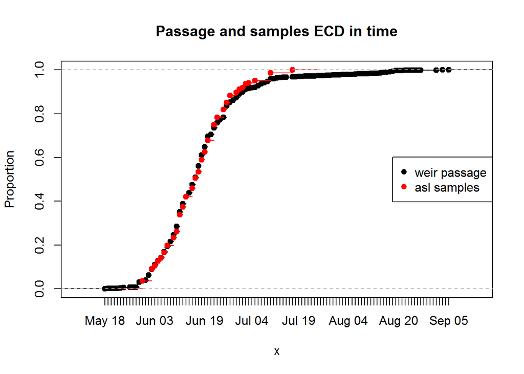

```
##
##  Two-sample Kolmogorov-Smirnov test
##
## data:  as.numeric(passage) and as.numeric(samples)
## D = 0.035548, p-value = 0.8763
## alternative hypothesis: two-sided
```

### Chinook sex composition

Likelihood ratio tests indicate sex composition was similar between time strata, which is further evidence we don’t need to stratify.

```
##
##         F   M Sum
##   1    28  38  66
##   2    37  40  77
##   3    36  33  69
##   4    32  39  71
##   Sum 133 150 283
```

```
##
##  Log likelihood ratio (G-test) test of independence without
##  correction
##
## data:  t.chinsex
## G = 1.4378, X-squared df = 3, p-value = 0.6967
```

Here is the Chinook sex-length table. We met the precision objective.

| sex_lab | Sample size | Proportion (SE) | 95% CI(Proportion) | Weir Passage(SE) | Mean Length (SE) | Range(Length) |
| --- | --- | --- | --- | --- | --- | --- |
| Females | 133 | 0.470 (0.029) | 0.413 - 0.528 | 5,349 (334) | 773.1 (3.5) | (660-890) |
| Males | 150 | 0.530 (0.029) | 0.472 - 0.587 | 6,033 (334) | 705.3 (11.0) | (440-970) |
| Both Sexes | 283 | 1.000 (0.000) |  | 11,383 (0) | 737.2 (6.4) | (440-970) |

### Chinook age composition

Likelihood ratio tests indicate age composition was similar between time strata, which is further evidence we don’t need to stratify.

```
##
##       1.1 1.2 1.3 1.4 Sum
##   1     3   9  40   6  58
##   2     3   8  53   5  69
##   3     5   6  42   5  58
##   4    10   5  33   6  54
##   Sum  21  28 168  22 239
```

```
##
##  Log likelihood ratio (G-test) test of independence without
##  correction
##
## data:  t.chinage
## G = 10.111, X-squared df = 9, p-value = 0.3416
```

Here is the Chinook age-length table. We met the precision objective.

| age_lab | Sample size | Proportion (SE) | 95% CI(Proportion) | Weir Passage(SE) | Mean Length (SE) | Range(Length) |
| --- | --- | --- | --- | --- | --- | --- |
| 1.1 | 21 | 0.088 (0.018) | 0.058 - 0.131 | 1,000 (206) | 499.5 (6.3) | (440-560) |
| 1.2 | 28 | 0.117 (0.021) | 0.082 - 0.164 | 1,333 (234) | 602.1 (10.8) | (505-740) |
| 1.3 | 168 | 0.703 (0.029) | 0.642 - 0.757 | 8,001 (333) | 776.5 (3.6) | (630-920) |
| 1.4 | 22 | 0.092 (0.019) | 0.062 - 0.135 | 1,047 (211) | 853.9 (14.3) | (710-970) |
| All ages | 239 | 1.000 (0.000) |  | 11,383 (0) | 738.9 (7.0) | (440-970) |

### Chinook age-sex composition

Here is the Chinook age-sex-length table.

| sex_lab | stat_lab | 1.1 | 1.2 | 1.3 | 1.4 | All ages |
| --- | --- | --- | --- | --- | --- | --- |
| Females | Sample size | NA | 3 | 105 | 7 | 115 |
| Females | Proportion (SE) | NA | 0.013 (0.007) | 0.439 (0.032) | 0.029 (0.011) | 0.481 (0.032) |
| Females | 95% CI(Proportion) | NA | 0.004 - 0.036 | 0.378 - 0.503 | 0.014 - 0.059 | 0.419 - 0.544 |
| Females | Weir Passage(SE) | NA | 142 (81) | 5,000 (362) | 333 (123) | 5,477 (364) |
| Females | Mean Length (SE) | NA | 710.0 (20.8) | 773.9 (3.8) | 810.7 (21.8) | 774.5 (3.9) |
| Females | Range(Length) | NA | (670-740) | (660-870) | (720-890) | (660-890) |
| Males | Sample size | 21 | 25 | 63 | 15 | 124 |
| Males | Proportion (SE) | 0.088 (0.018) | 0.105 (0.020) | 0.264 (0.028) | 0.063 (0.016) | 0.519 (0.032) |
| Males | 95% CI(Proportion) | 0.058 - 0.131 | 0.072 - 0.150 | 0.212 - 0.323 | 0.038 - 0.101 | 0.456 - 0.581 |
| Males | Weir Passage(SE) | 1,000 (206) | 1,190 (223) | 3,000 (321) | 714 (177) | 5,905 (364) |
| Males | Mean Length (SE) | 499.5 (6.3) | 589.2 (8.8) | 780.9 (7.2) | 874.0 (16.3) | 705.8 (12.4) |
| Males | Range(Length) | (440-560) | (505-665) | (630-920) | (710-970) | (440-970) |
| Both Sexes | Sample size | 21 | 28 | 168 | 22 | 239 |
| Both Sexes | Proportion (SE) | 0.088 (0.018) | 0.117 (0.021) | 0.703 (0.029) | 0.092 (0.019) | 1.000 (0.000) |
| Both Sexes | 95% CI(Proportion) | 0.058 - 0.131 | 0.082 - 0.164 | 0.642 - 0.757 | 0.062 - 0.135 |  |
| Both Sexes | Weir Passage(SE) | 1,000 (206) | 1,333 (234) | 8,001 (333) | 1,047 (211) | 11,383 (0) |
| Both Sexes | Mean Length (SE) | 499.5 (6.3) | 602.1 (10.8) | 776.5 (3.6) | 853.9 (14.3) | 738.9 (7.0) |
| Both Sexes | Range(Length) | (440-560) | (505-740) | (630-920) | (710-970) | (440-970) |

## Coho SL

Note there was one record with a length of 55cm. I changed this to 550, let me know if that’s incorrect.

```
## # A tibble: 1 x 4
##         date   sex length strata
##       <dttm> <chr>  <dbl>  <chr>
## 1 2017-08-11     M     55      4
```

Sex composition of coho salmon does not differ between time strata, indicating pooled ASL estimates are sufficient.

```
##
##         F   M Sum
##   3    23  36  59
##   4    33  42  75
##   5    62  93 155
##   6    19  31  50
##   Sum 137 202 339
```

```
##
##  Pearson's Chi-squared test
##
## data:  tab
## X-squared = 0.5827, df = 3, p-value = 0.9004
```

Here is the pooled coho sex-length table. We met the precision objective.

| sex_lab | Sample size | Proportion (SE) | 95% CI(Proportion) | Weir Passage(SE) | Mean Length (SE) | Range(Length) |
| --- | --- | --- | --- | --- | --- | --- |
| Females | 137 | 0.404 (0.027) | 0.353 - 0.457 | 14,899 (979) | 556.3 (2.5) | (475-625) |
| Males | 202 | 0.596 (0.027) | 0.543 - 0.647 | 21,969 (979) | 549.5 (2.8) | (410-630) |
| Both Sexes | 339 | 1.000 (0.000) |  | 36,869 (0) | 552.3 (1.9) | (410-630) |

I also stratified the coho sex comp to compare. Here is stratified coho sex-length table.

| sex_lab | Sample size | Proportion (SE) | 95% CI(Proportion) | Weir passage(SE) | Mean Length (SE) | Range(Length) |
| --- | --- | --- | --- | --- | --- | --- |
| Females | 137 | 0.401 (0.028) | 0.345 - 0.456 | 14,769 (1,041) | 556.7 (2.6) | (475-625) |
| Males | 202 | 0.599 (0.028) | 0.544 - 0.655 | 22,096 (1,041) | 552.2 (2.9) | (410-630) |
| Both Sexes | 339 | 1.000 (0.000) |  | 36,869 (0) | 554.0 (2.0) | (410-630) |